# 06 – Run A: does the network support the paper’s Notch claim?

Reading the stroma → early lymphoid network around DLL4/JAG2 → NOTCH1

Author

Minh Le, Jeanne Leclerc

Published

October 15, 2026

## Question

Park *et al.* write that “NOTCH1 is the main receptor expressed in early thymic progenitors (ETPs)” and that “cTECs and endothelial cells express both JAG2 and DLL4, and other TECs broadly express JAG1”. Run A (notebook 05) built a CausalCCC network with these pairs imposed between stromal senders and early lymphoid receivers. Here we ask:

1. Did adding sequencing depth as a variable remove the depth-driven links seen in the first run?
2. On the sender side, what is the expression of the Notch ligands associated with – stromal population, donor, other genes?
3. On the receiver side, does NOTCH1 connect to its known targets (HES1, DTX1, NRARP, PTCRA)?

**How to read the network.** Each side’s links are learnt from its own cells only: stromal genes from the 1,555 stromal cells, lymphoid genes from the 2,622 lymphoid cells. The L–R links between the two sides are imposed by CausalCCC, not found. A retained link means the two variables stay dependent whatever other variables are taken into account; an arrow is an orientation inferred by MIIC; “genuine causation” (`is_causal`) marks orientations that MIIC considers free of hidden common causes.

## Setup

```r
library(tidyverse)
library(Matrix)

find_repo_root <- function(dir = getwd()) {
  while (!(file.exists(file.path(dir, "README.md")) && dir.exists(file.path(dir, "notebooks")))) {
    parent <- dirname(dir)
    if (parent == dir) stop("Repository root not found. Open the repository folder in Positron.")
    dir <- parent
  }
  dir
}
root <- find_repo_root()
source(file.path(root, "scripts", "helpers.R"))   # network drawing functions (case study 2)

run_dir  <- file.path(root, "results", "thymus_early", "05_runA_causalccc")
fig_dir  <- file.path(root, "results", "figures", "thymus_early")
dir.create(fig_dir, recursive = TRUE, showWarnings = FALSE)

read_run <- function(dir) {
  result <- readRDS(file.path(dir, "miic_result.rds"))
  list(edges = result$all.edges.summary,
       state_order = read_tsv(file.path(dir, "state_order.tsv"), show_col_types = FALSE),
       lr = read_tsv(file.path(dir, "interact_edges.tsv"), col_names = c("ligand", "receptor"),
                     show_col_types = FALSE))
}
with_depth    <- read_run(file.path(run_dir, "miic_input"))
without_depth <- read_run(file.path(run_dir, "miic_input_without_depth"))

# Retained links, one row per link. The L-R pairs appear twice in this miic version (an empty placeholder and the
# imposed link, case study 1 notebook 02); the placeholder (Nxy_ai = 0) is dropped.
retained <- function(run) {
  run$edges |>
    filter(type == "P") |>
    arrange(Nxy_ai %in% 0) |>
    distinct(link = link_name(x, y), .keep_all = TRUE) |>
    mutate(is_lr = link %in% link_name(run$lr$ligand, run$lr$receptor))
}
net <- retained(with_depth)
net_without <- retained(without_depth)

# Side of each variable, for colours and for "within one side" statistics
side_of <- function(state_order) {
  setNames(case_when(state_order$group == "metadata" ~ "metadata",
                     state_order$group %in% c("ligands", "senders genes") ~ "stroma",
                     .default = "early lymphoid"),
           state_order$var_names)
}
side <- side_of(with_depth$state_order)
# Label: gene without suffix; metadata variables keep their side (population of the stromal or of the lymphoid cells)
label <- function(v) {
  base <- str_remove(v, "_(senders|receivers)$")
  case_when(str_ends(v, "_senders") & side[v] == "metadata" ~ paste(base, "(stroma)"),
            str_ends(v, "_receivers") & side[v] == "metadata" ~ paste(base, "(lymphoid)"),
            .default = base)
}

# Colours of the drawing helpers, redefined for this analysis
cell_type_colours <- c(stroma = "#b5d99c", `early lymphoid` = "#f2c57c", metadata = "#d9d9d9")
cell_type_borders <- c(stroma = "#4f7a28", `early lymphoid` = "#a8742a", metadata = "#7f7f7f")

notch_ligands <- c("DLL4", "JAG2", "JAG1", "DLL1")
notch_targets <- c("HES1", "DTX1", "NRARP", "PTCRA")
```

## 1. Overview

```r
category <- function(n, side) {
  n |> mutate(category = case_when(is_lr ~ "imposed L-R link",
                                   side[x] == "metadata" | side[y] == "metadata" ~ "link to a metadata variable",
                                   side[x] == "stroma" ~ "within stroma",
                                   .default = "within early lymphoid"))
}
bind_rows(`without depth` = count(category(net_without, side_of(without_depth$state_order)), category),
          `with depth`    = count(category(net, side), category), .id = "run") |>
  pivot_wider(names_from = run, values_from = n)
```

```
# A tibble: 4 × 3
  category                    `without depth` `with depth`
  <chr>                                 <int>        <int>
1 imposed L-R link                         27           27
2 link to a metadata variable             122          166
3 within early lymphoid                   261          207
4 within stroma                           181          158
```

```r
# How many genes each metadata variable is directly linked to
net |>
  filter(side[x] == "metadata" | side[y] == "metadata") |>
  mutate(metadata = if_else(side[x] == "metadata", x, y)) |>
  count(metadata, name = "linked_variables") |>
  arrange(desc(linked_variables))
```

```
              metadata linked_variables
1   population_senders               58
2 population_receivers               48
3   n_counts_receivers               29
4     n_counts_senders               15
5      donor_receivers                8
6        donor_senders                8
```

**Reading.** With depth as a variable, links between genes of the same side decrease (stroma 181 → 158, lymphoid 261 → 207) and links to metadata variables increase (122 → 166): part of what looked like gene–gene dependence is now attributed to a metadata variable. The two `population` variables are the largest hubs (58 and 48 variables): the groups merge several populations, so every gene that differs between populations links to them. Depth is linked to 29 lymphoid and 15 stromal variables, donor to 8 on each side. Chemistry (`method`) has no direct link: what it explains is apparently already carried by donor and population.

## 2. Did the depth variable remove the depth-driven links?

For every gene of the network we compute, within each population, the Spearman correlation between its counts and the total counts of the cell, and keep the median over populations. Genes above 0.5 “follow depth”. We then compare the two runs: how often a gene–gene link joins two such genes, and what NOTCH1 is linked to.

```r
input_dir <- file.path(root, "results", "thymus_early", "04_runA_input")
counts <- readMM(gzfile(file.path(input_dir, "counts.mtx.gz")))
genes  <- read_csv(file.path(input_dir, "genes.csv"), show_col_types = FALSE)$gene
cells  <- read_csv(file.path(input_dir, "cells.csv"), show_col_types = FALSE)
group_of_side <- c(stroma = "stroma", `early lymphoid` = "early_lymphoid")

gene_vars <- names(side)[side != "metadata"]
depth_rho <- map_dbl(gene_vars, \(v) {
  in_group <- cells$group == group_of_side[[side[[v]]]]
  x <- counts[match(label(v), genes), ]
  rhos <- map_dbl(unique(cells$population[in_group]), \(p) {
    m <- in_group & cells$population == p
    if (sd(x[m]) == 0) NA_real_ else cor(x[m], cells$n_counts[m], method = "spearman")
  })
  median(rhos, na.rm = TRUE)
}) |> setNames(gene_vars)
rm(counts)
follows_depth <- names(depth_rho)[depth_rho > 0.5]
length(follows_depth)
```

```
[1] 96
```

```r
depth_module <- function(n) {
  gene_gene <- n |> filter(!is_lr, x %in% gene_vars, y %in% gene_vars)
  tibble(gene_gene_links = nrow(gene_gene),
         both_follow_depth = sum(gene_gene$x %in% follows_depth & gene_gene$y %in% follows_depth),
         share = both_follow_depth / gene_gene_links,
         expected_by_chance = (length(follows_depth) / length(gene_vars))^2)
}
bind_rows(`without depth` = depth_module(net_without), `with depth` = depth_module(net), .id = "run") |>
  mutate(across(c(share, expected_by_chance), \(v) round(v, 3)))
```

```
# A tibble: 2 × 5
  run           gene_gene_links both_follow_depth share expected_by_chance
  <chr>                   <int>             <int> <dbl>              <dbl>
1 without depth             442               149 0.337              0.138
2 with depth                365                87 0.238              0.138
```

```r
neighbours_in <- function(n, node) sort(c(n$y[n$x == node], n$x[n$y == node]))
list(`NOTCH1, without depth` = neighbours_in(net_without, "NOTCH1"),
     `NOTCH1, with depth`    = neighbours_in(net, "NOTCH1"))
```

```
$`NOTCH1, without depth`
[1] "DLK1"  "DLL1"  "DLL4"  "H2AFY" "JAG1"  "JAG2"  "MTF2"  "TFDP2"

$`NOTCH1, with depth`
[1] "CD99_receivers"     "DLK1"               "DLL1"
[4] "DLL4"               "JAG1"               "JAG2"
[7] "n_counts_receivers"
```

**Reading.** The share of gene–gene links joining two depth-following genes falls from 34% to 24% (13.8% expected by chance): the depth variable removes part of the depth module, not all of it. NOTCH1’s three housekeeping neighbours (H2AFY, MTF2, TFDP2) are gone; NOTCH1 is now linked to depth itself and to CD99, which also follows depth (ρ = 0.60). So part of the cell-to-cell variation of NOTCH1 counts reflects sequencing depth.

## 3. Sender side: what is the expression of the Notch ligands associated with?

```r
orientation_from <- function(n, node) {
  neighbors_of(node, n) |>
    mutate(neighbor_side = side[neighbor],
           depth_rho = round(depth_rho[neighbor], 2),
           arrow = case_when(direction == "out" ~ paste(label(node), "->", label(neighbor)),
                             direction == "in" ~ paste(label(neighbor), "->", label(node)),
                             .default = direction)) |>
    select(node, neighbor, neighbor_side, arrow, is_causal, depth_rho)
}
map(c(notch_ligands, "NOTCH1"), \(g) orientation_from(net, g)) |> bind_rows()
```

```
     node           neighbor  neighbor_side          arrow is_causal depth_rho
1    DLL4 population_senders       metadata           none         N        NA
2    DLL4             NOTCH1 early lymphoid DLL4 -> NOTCH1         N      0.37
3    JAG2 population_senders       metadata           none         N        NA
4    JAG2       GNAS_senders         stroma           none         N      0.79
5    JAG2             NOTCH1 early lymphoid JAG2 -> NOTCH1         N      0.37
6    JAG1               HES4         stroma           none         N      0.21
7    JAG1             IGFBP2         stroma           none         N      0.67
8    JAG1             NOTCH1 early lymphoid JAG1 -> NOTCH1         N      0.37
9    DLL1             PLXND1         stroma           none         N      0.04
10   DLL1             NOTCH1 early lymphoid DLL1 -> NOTCH1         N      0.37
11 NOTCH1 n_counts_receivers       metadata           none         N        NA
12 NOTCH1     CD99_receivers early lymphoid           none         N      0.60
13 NOTCH1               DLL4         stroma DLL4 -> NOTCH1         N      0.23
14 NOTCH1               JAG1         stroma JAG1 -> NOTCH1         N      0.23
15 NOTCH1               JAG2         stroma JAG2 -> NOTCH1         N      0.32
16 NOTCH1               DLL1         stroma DLL1 -> NOTCH1         N      0.15
17 NOTCH1               DLK1         stroma DLK1 -> NOTCH1         N      0.30
```

```r
centres <- c(notch_ligands, "NOTCH1", notch_targets)
notch_net <- network_data(net, link_name(with_depth$lr$ligand, with_depth$lr$receptor), side, label,
                          centres = centres, max_distance = 1)
plot_network_interactive(notch_net, title = "Notch claim genes and their direct neighbours (run A)")
```

[interactive chart not shown]

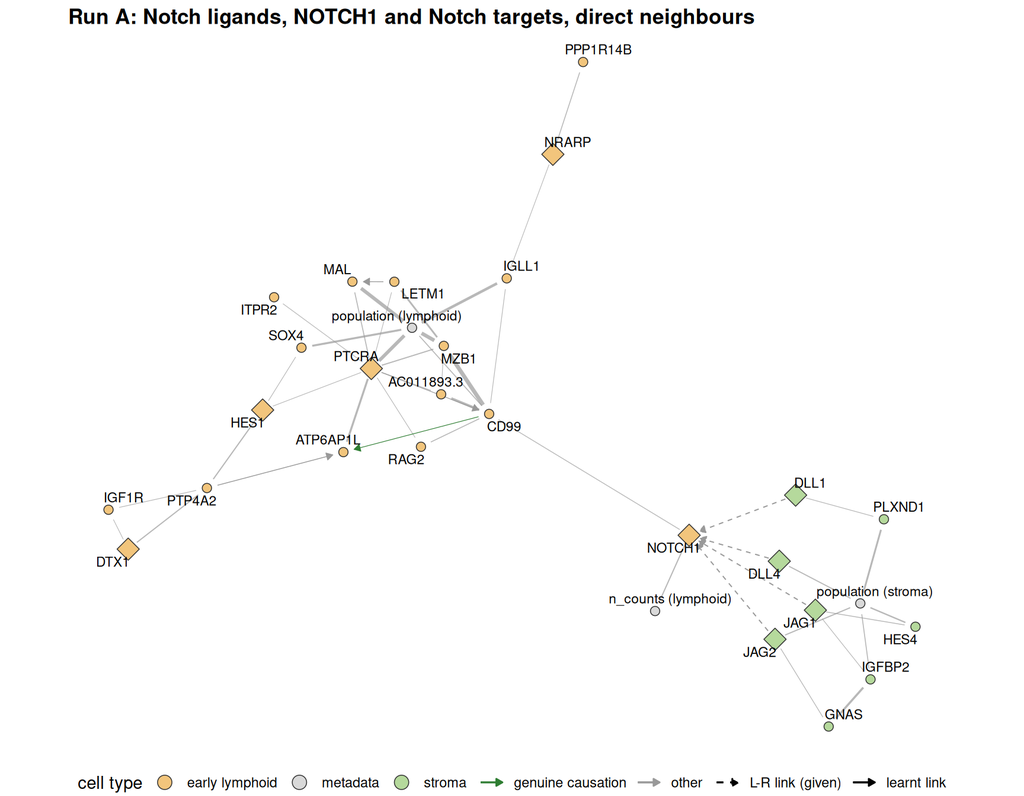

```r
static <- plot_network_static(notch_net, title = "Run A: Notch ligands, NOTCH1 and Notch targets, direct neighbours")
ggsave(file.path(fig_dir, "06_notch_neighbourhood.png"), static, width = 10, height = 8, dpi = 200)
static
```

**Reading – sender side.**

- **DLL4 and JAG2 are linked to the stromal population** (and JAG2 to GNAS, a depth-following gene). Their expression is explained by which population a stromal cell belongs to. This agrees with the paper’s statement: in notebook 03, JAG2 is detected in 56% of cTECs and 39% of endothelial cells, DLL4 in 34% and 49%, and both are almost absent from Fb_1.
- **JAG1** is linked to HES4 and IGFBP2, and **DLL1** to PLXND1. None of these links is oriented.
- In the stroma, population and donor are strongly linked (cTEC come almost only from C40/C41, notebook 02), so “linked to population” cannot be fully separated from “linked to donor”.

**Receiver side.** Besides the imposed links from its five ligands, NOTCH1 is linked only to depth and CD99.

## 4. Receiver side: is NOTCH1 connected to its targets?

The shortest path from NOTCH1 to each target through lymphoid genes only (paths through a metadata variable are not counted: two genes both linked to “population” are not connected biologically).

```r
lymphoid <- net |> filter(!is_lr, side[x] == "early lymphoid", side[y] == "early lymphoid")
graph <- igraph::graph_from_data_frame(select(lymphoid, x, y), directed = FALSE)
map(notch_targets, \(t) {
  if (!all(c("NOTCH1", t) %in% igraph::V(graph)$name)) return(tibble(target = t, steps = NA, path = "not connected"))
  p <- igraph::shortest_paths(graph, "NOTCH1", t)$vpath[[1]]$name
  tibble(target = t, steps = if (length(p)) length(p) - 1 else NA,
         path = if (length(p)) paste(label(p), collapse = " – ") else "not connected")
}) |> bind_rows()
```

```
# A tibble: 4 × 3
  target steps path
  <chr>  <dbl> <chr>
1 HES1       3 NOTCH1 – CD99 – PTCRA – HES1
2 DTX1       4 NOTCH1 – CD99 – ATP6AP1L – PTP4A2 – DTX1
3 NRARP      3 NOTCH1 – CD99 – IGLL1 – NRARP
4 PTCRA      2 NOTCH1 – CD99 – PTCRA
```

```r
map(notch_targets, \(g) orientation_from(net, g)) |> bind_rows()
```

```
    node             neighbor  neighbor_side         arrow is_causal depth_rho
1   HES1               PTP4A2 early lymphoid          none         N      0.63
2   HES1                 SOX4 early lymphoid          none         N      0.50
3   HES1                PTCRA early lymphoid          none         N      0.23
4   DTX1               PTP4A2 early lymphoid          none         N      0.63
5   DTX1                IGF1R early lymphoid          none         N      0.23
6  NRARP             PPP1R14B early lymphoid          none         N      0.30
7  NRARP                IGLL1 early lymphoid          none         N      0.32
8  PTCRA population_receivers       metadata          none         N        NA
9  PTCRA             ATP6AP1L early lymphoid          none         N      0.17
10 PTCRA                 MZB1 early lymphoid          none         N      0.55
11 PTCRA                  MAL early lymphoid          none         N      0.25
12 PTCRA           AC011893.3 early lymphoid          none         N      0.39
13 PTCRA                ITPR2 early lymphoid          none         N      0.27
14 PTCRA                 RAG2 early lymphoid          none         N      0.23
15 PTCRA       CD99_receivers early lymphoid PTCRA -> CD99         N      0.60
16 PTCRA                 HES1 early lymphoid          none         N      0.28
17 PTCRA                LETM1 early lymphoid          none         N      0.36
```

**Reading.**

- **NOTCH1 is not directly linked to any of its targets.** The shortest lymphoid paths go through CD99: PTCRA in 2 steps, HES1 and NRARP in 3, DTX1 in 4.
- **The targets sit in a T-lineage module**: PTCRA is linked to HES1, RAG2, MAL and to the lymphoid population variable; NRARP to IGLL1 (pre-B/pre-T receptor component). They vary with the developmental stage of the cells (ETP, DN(early), DN(P/Q), versus ILC3/NK/γδT), which is what Notch signalling drives in early T-cell development.
- **Why NOTCH1 itself may not connect:** Notch signalling is activated by ligand-induced cleavage of the receptor protein, not by more receptor mRNA. Target genes report pathway activity; NOTCH1 counts mostly report receptor availability. The absence of a direct NOTCH1 → target link is therefore not evidence against Notch signalling, but the network does not give direct support for it either.

## Summary

| Question | Answer from run A |
| --- | --- |
| Did the depth variable help? | Partly: links within the depth module fall from 34% to 24% of gene–gene links (13.8% by chance); NOTCH1’s housekeeping neighbours disappear |
| Notch ligands, sender side | DLL4 and JAG2 depend on the stromal population, consistent with the paper (expressed by cTEC and Endo, not Fb_1); population and donor are confounded in the stroma |
| NOTCH1, receiver side | Linked only to depth and CD99, besides the imposed ligands |
| Notch targets | Not directly linked to NOTCH1; they form a T-lineage module (PTCRA, HES1, RAG2, IGLL1) that follows the lymphoid population |

**What this means for the claim.** The network is consistent with the *expression* part of the claim (who expresses the ligands), which is what the paper’s dot plot showed. It does not add causal support for the *signalling* part: the receptor’s mRNA is not connected to its targets, which is expected given how Notch is activated, and which a gene expression network cannot resolve.

**Limits.** The L–R links are imposed, not inferred. In the stroma, population and donor are confounded. The depth module is reduced but not removed. Run B (lymphoid → stroma) tests the claims in the other direction.